# HW4_B66043

Dzvezdana Arsovska

March 07, 2017

## Exercise 1

Summarize the key take-home messages from the video presentation by Tamara Munzner: Keynote on Visualization Principles.

**Solution:**

Professor Tamara Munzner presents some useful guidelines for creating effective visualizations.

In the first part of the video she explains how better understanding of the data help people to carry out some tasks better. She points out that if your representation of the data does not make data clearer, you need a better visual Chanel.

After explaining different data types she points out which visual channels are the best for them (in a ranking list). For example categorical data (what/where) and ordered data (ordinal/quantitative) require different visual channels. Otherwise the visualization can become miss communicating. (Example: We can use changes in hue for categorical data but not for ordered data).

The channel rankings was created based on the effectiveness principles and the rankings were created based on:

- accuracy (for example we accurately notice position along common scale)
- discriminability (for example how to use color so people can notice difference and understand the data)
- separability (how to use different channels to get fully separable representation without interference)
- pop out (we easily notice sufficiently different item but only one channel at the time has to be used)

In the second part of the video she stresses out the drawbacks of:

- 3D visualization;

3D visualization should be used only in rare cases and when it is actually needed because it has major drawbacks.Some of the drawbacks are the interaction complexity, the loss of the subtle patterns and that we are not able to notice details and make detailed comparisons.

- Immersion;

Immersion often is not helpful and resolution is much more important.

- Animation;

External cognition is better than animation because global comparison using our memory is hard.

In the last part of the video she explains how to validate visualizations and how to identify the right threat. Before we create data visualization we need to have solid understanding of the problem gained by interviewing and observing the target users. This will helps to show the right things in the right way. In the end we also need to consider the complexity of out algorithm.

## Exercise 2

Fetch the UK child height/weight measurements data NHS web.

Study a sufficiently large random subset of measurements. Pay attention and comment on how did you make a random subset? What is it representative of? Be ready to use external scripts (subsetting data with some tools/scripts before reading it in R/Python) rather than reading all data in at once.

Make two nice, interesting and informative plots for example by using scatterplots - comparing age, gender, height, weight, BMI, school deprivation data (choose some). Incorporate categorical features (or actually you can do it even with continuous ones) by playing with color of the points.

**Solution:**

The NHS data set consists of $1169941$ rows and $24$ columns that from describe two groups of children, one in reception and one in grade $6$. Using this data set we can get information about childern’s weight, place of living, bmi score etc.

We can read this large data set in R using the data.table library and the fread function:

```r
library(data.table)
mydata <- fread("C:/Users/arsov/OneDrive/Documents/ncmp_1516_final_non_disclosive_rand_id_published.csv")
```

A random sample is a subset chosen from a larger set. Each row is chosen randomly and entirely by chance, such that each row has the same probability of being chosen at any stage during the sampling process. For this task I am using sampling without replacement which means that each row can not be chosen more than once.

```r
mysample <- mydata[sample(1:nrow(mydata), 175491, replace = FALSE), ]
```

The size of the chosen random sample is $175491$ rows (15% of the data), which is big enough to derive useful conclusion from the data without disturbing the general picture, and small enough from computational point of view meaning that the size is small enough for creating a plot that is not too large.

If we inspect the range of the values of the features height and weight we can notice that they have negative values. We can replace them with $NA$ and than remove them.

```r
mysample$height[mysample$height < 0] <- NA
mysample$weight[mysample$weight < 0] <- NA
mysample <- na.omit(mysample)
```

By doing so we are removing $851$ rows and we are left with $174640$ or about 14.93% which is still large enough number.

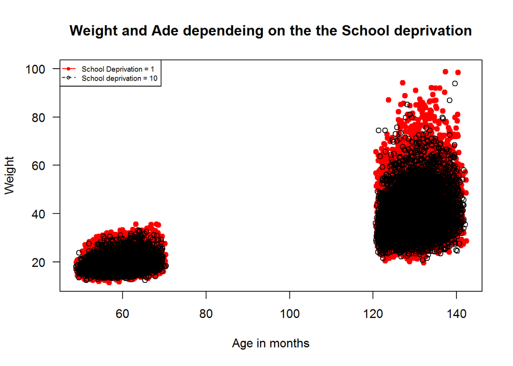

```r
plot(weight ~ ageinmonths, mysample, xlab = "Age in months", ylab = "Weight",
    type = "n", las = 1)
points(weight ~ ageinmonths, mysample, subset = schoolindexofmultipledepriv ==
    1, pch = 19, col = "red")
points(weight ~ ageinmonths, mysample, subset = schoolindexofmultipledepriv ==
    10, pch = 1, col = "black")
legend("topleft", pch = c(19, 1), legend = c("School Deprivation = 1", "School deprivation = 10"),
    col = c("red", "black"), lty = 1:2, cex = 0.6)
title("Weight and Ade dependeing on the the School deprivation")
```

On this scatterplot I am comparing weight and age for two different levels of school deprivation ($1$ represents the biggest deprivation and $10$ the smallest). From this plot we can notice that children that are deprived from school have a higher tendency towards having an increased weight and the number of school deprived overweight children increases as they age. In other words the number of overweight children between $10$ and $11$ that are school deprived is higher than those in reception.

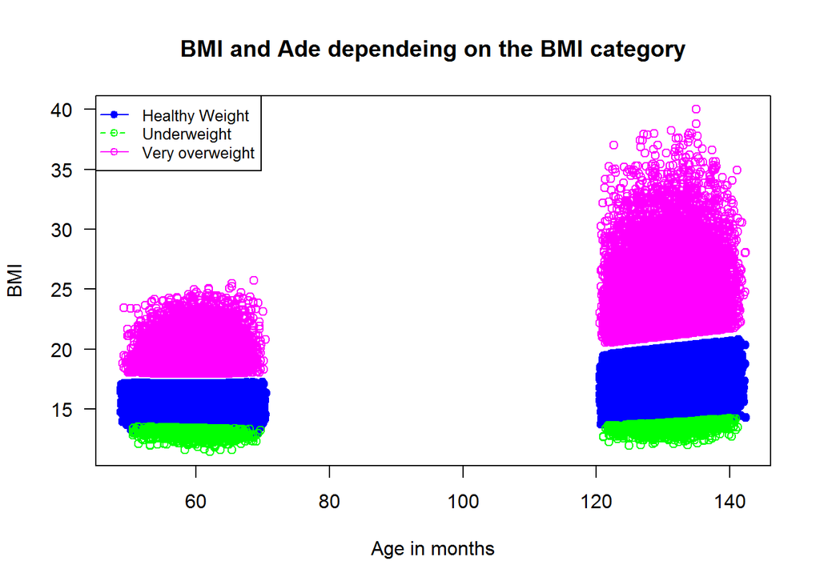

```r
plot(bmi ~ ageinmonths, mysample, xlab = "Age in months", ylab = "BMI", type = "n",
    las = 1)
points(bmi ~ ageinmonths, mysample, subset = bmipopulationcategory == "healthy weight",
    pch = 19, col = "blue")
points(bmi ~ ageinmonths, mysample, subset = bmipopulationcategory == "underweight",
    pch = 1, col = "green")
points(bmi ~ ageinmonths, mysample, subset = bmipopulationcategory == "very overweight",
    pch = 1, col = "magenta")
legend("topleft", pch = c(19, 1, 1), legend = c("Healthy Weight", "Underweight",
    "Very overweight"), col = c("blue", "green", "magenta"), lty = 1:2, cex = 0.8)
title("BMI and Ade dependeing on the BMI category")
```

On this scatterplot I am comparing the BMI index and the age for different levels of the BMI index: healthy weight, underweight and overweight. We can notice that the number of overweight children increase as the children are older. Also the prevalence of underweight children was higher in year 6 than in reception.

## Exercise 3

Here is a small set of transactions over 8 possible items. Identify all frequent item sets that have support of 5 or more. For that follow and describe apriori principle. You have to be quite clever in keeping track of all possible frequent item sets. Feel free to create some small scripts or helpers for tabulations - on paper you also need to organize data well.

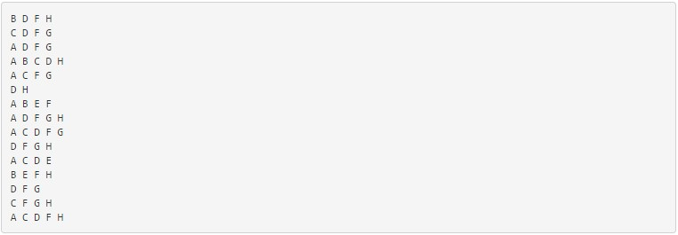

**Solution:**

In data mining, the apriori algorithm is a popular method that uses uses a set of transactions for discovering interesting relations between variables in large databases. Apriori calculates the probability of an item being present in a frequent item set, given that another item or items is present. The steps for calculating the frequent item sets are shown in the following tables. Marked with red are the sets that do not satisfy the condition for the minimum count of $5$. At the end we are left with only one 3 element set $DFG$ that has support of $6$.

The counting of the frequency of the letters in each transaction was done using the following Python code:

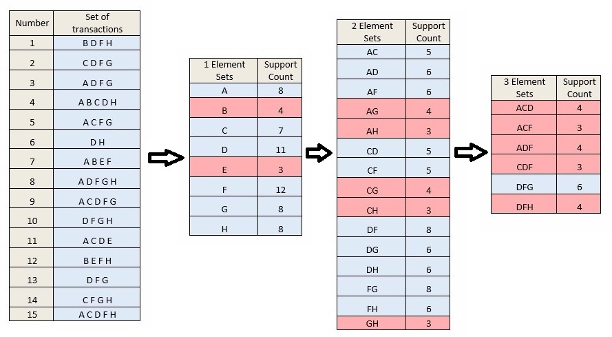

```python
# mytext.txt contains all transaction sets;
# counting the number of occurence of C and D in all transactions;

for word in file('mytex.txt').read().split():
    if 'C' in word and 'D':
        print word
```

## Exercise 4

Pick some largest frequent item sets from above and generate association rules from them. Which have the highest confidence and lift values?

**Solution:**

Rules have an associated confidence, which is the conditional probability that the consequent will occur given the occurrence of the antecedent.

Confidence is an indication of how often the rule has been found to be true.

The confidence of an association rule R = “X -> Y” (with item sets X and Y) is the support of the set of all items that appear in the rule (here: the support of $S = X \cup Y$) divided by the support of the antecedent of the rule (here X).

$$conf(R) = \frac{sup(X \cup Y)}{sup(X)}$$

Both support and confidence must be used to determine if a rule is valid. However, there are times when both of these measures may be high, and yet still produce a rule that is not useful. A third measure is needed to evaluate the quality of the rule. Lift on the other hand says how likely item Y is purchased when item X is purchased, while controlling for how popular item Y is.

$$lift(R) = \frac{\frac{sup(X \cup Y)}{sup(X)}}{\frac{sup(X)sup(Y)}{num\; transactions}} = \frac{P(Y|X)}{P(Y)}$$

If Lift = 1, X and Y are not independent. If Lift > 1, X and Y are positively correlated. If Lift < 1, X and Y are negatively correlated.

In the following table we can see the values for the confidence and the lift the most frequent data sets for Exercise 3.

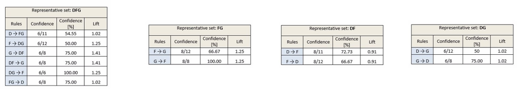

The rules with the highest confidence (100%) are DG -> F and G -> F. The also have high lift values of $1.25$. However they do not have the highest lift value. Rules G -> DF and DF -> G have lift of $1.41$ which is the highest lift.

The rule DG -> F has confidence of 100% and lift of $1.25$, which makes it a strong rule. If we take the letters to represent Diapers, Grapes and Fish this rule can be interpreted as that people who buy Diapers and Grapes also buy Fish. In other words, {Diapers, Grapes} implies {Fish}.

A rule that is not so strong is for example D -> G which has confidence of 50% and lift of $1.02$. This implies that this association is not so strong.

In the rule D -> F and F -> D we have negative correlation. Any rule with an improvement of less than 1 does not indicate a real cross-selling opportunity, no matter how high its support and confidence are, because it actually offers less ability to predict a purchase than does random chance.

## Exercise 5

Get the Titanic survival data from https://courses.cs.ut.ee/MTAT.03.183/2014_spring/uploads/Main/titanic.txt.

Find interesting associations from that data. Report clearly the most “interesting” rules discovered from Titanic data, and how you came up with those in R or Python or some command line packages for association rules (see Wikipedia). If you selected the most interesting rules by some measure (support, confidence, lift), interpret the meaning of the measure on those rules.

**Solution:**

```r
x1 <- fread("C:/Users/arsov/OneDrive/Documents/titanic-txt.csv")
Titanic <- data.frame(sapply(x1, as.factor))
rules <- apriori(Titanic)
```

Even if we run the apriori algorithm in R with the default settings we can derive several interesting rules.

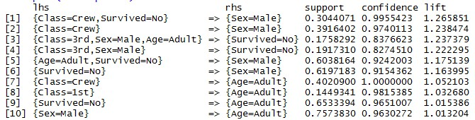

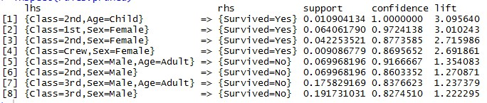

```r
# rules with rhs containing 'Survived' only
rules <- apriori(Titanic, parameter = list(minlen = 2, supp = 0.005, conf = 0.8),
    appearance = list(rhs = c("Survived=No", "Survived=Yes"), default = "lhs"),
    control = list(verbose = F))
# sort rules
rules.sorted <- sort(rules, by = "lift")

# find redundant rules
subset.matrix <- is.subset(rules.sorted, rules.sorted)
subset.matrix[lower.tri(subset.matrix, diag = T)] <- NA
redundant <- colSums(subset.matrix, na.rm = T) >= 1
which(redundant)

# remove redundant rules
rules.pruned <- rules.sorted[!redundant]
inspect(rules.pruned)
```

If we change the default values for the confidence and the lift and we find the rules which show if a person survived or not, we can notice that women and children for first and second class had higher chance for survival compared to second and third class man. The rules are sorted by the lift(by the measure of the performance for the algorithm) and the redundant rules are pruned. The same principal will be followed for the next case.

```r
rules <- apriori(Titanic, parameter = list(minlen = 3, supp = 0.002, conf = 0.2),
    appearance = list(default = "none", rhs = c("Survived=Yes"), lhs = c("Class=1st",
        "Class=2nd", "Class=3rd", "Age=Adult", "Age=Child")), control = list(verbose = F))
```

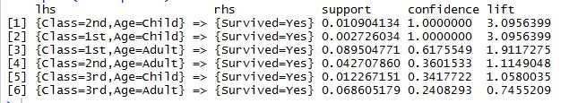

In the above result, the first two rules show that we are most confident that first and second class children survived. On the other hand that was not the case with third class children who have smaller survival rate.

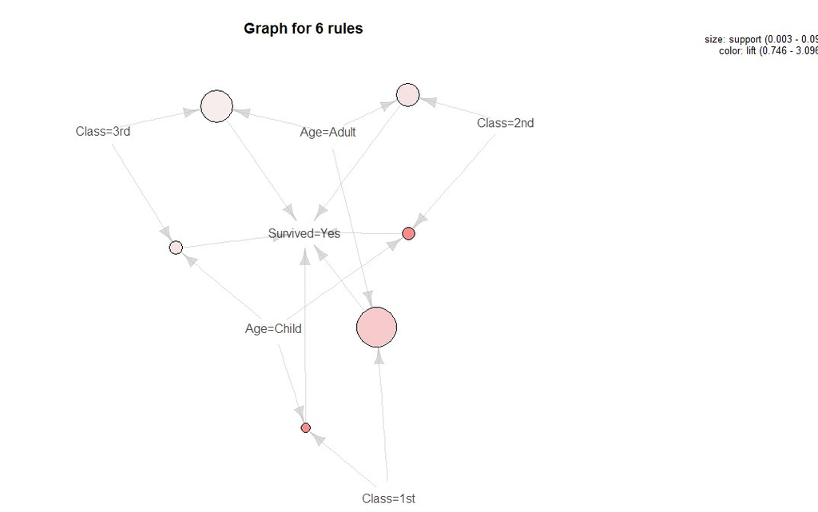

## Exercise 6

Perform more analysis of height+weight data. Make a compelling story - comparing deprived regions against better off regions; or any other criterion that you can observe from data. Idea - show some very clear differences for children depending on their background. For example use the distance to nearest school; school deprivation information.

**Solution:**

```r
library(ggplot2)
p1 <- ggplot(mysample) + aes(bmipopulationcategory, fill = genderdescription)
p1 <- p1 + ggtitle("BMI-Gender comparison for different regions")
p1 <- p1 + geom_bar(position = "dodge") + ylab("BMI") + xlab("Count")
p1 <- p1 + scale_fill_discrete() + coord_flip()
p1 <- p1 + facet_wrap(~schoolgovernmentofficeregion)
```

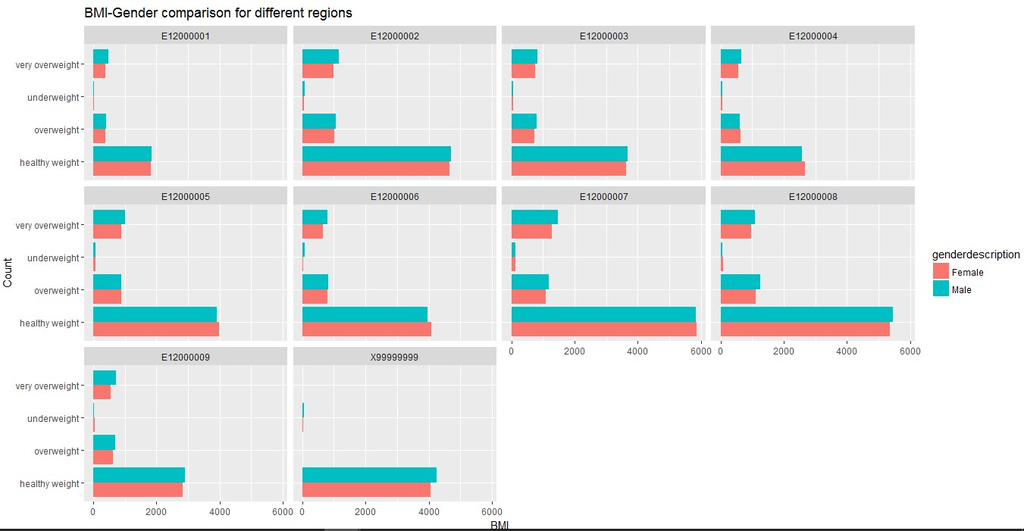

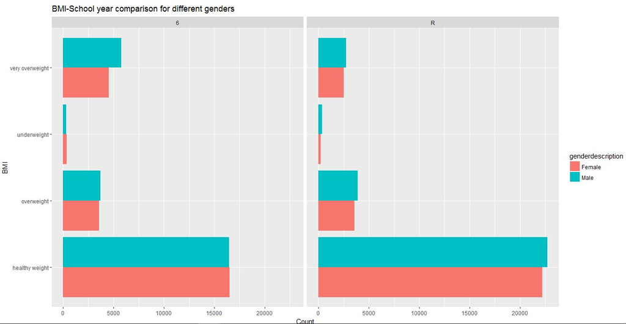

```r
p2 <- ggplot(mysample) + aes(bmipopulationcategory, fill = genderdescription)
p2 <- p2 + ggtitle("BMI-School year comparison for different genders")
p2 <- p2 + geom_bar(position = "dodge") + ylab("Count") + xlab("BMI")
p2 <- p2 + scale_fill_discrete() + coord_flip()
p2 <- p2 + facet_wrap(~schoolyear)
```

For example we can check if the school deprivation is highest in this region. The plot that compares the school deprivation for different regions and school years clearly shows that the region E12000002 has the highest level of deprivation. This means that we can link school deprivation with obesity.

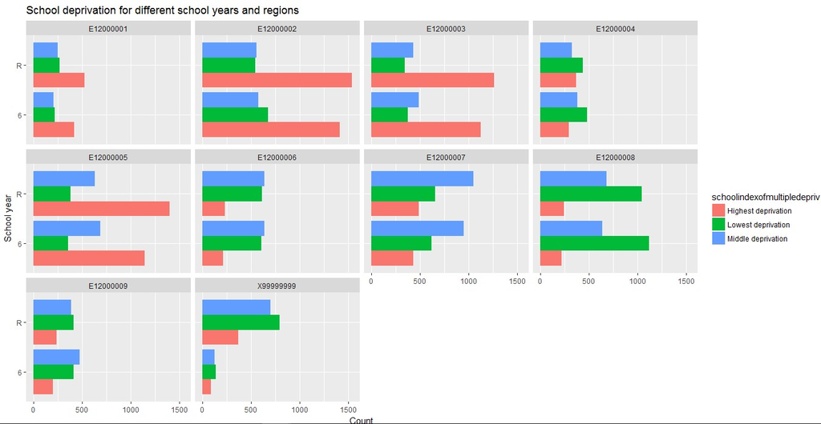

```r
mysam$schoolindexofmultipledepriv <- gsub(1, "Highest deprivation", mysam$schoolindexofmultipledepriv)
mysam$schoolindexofmultipledepriv <- gsub(5, "Middle deprivation", mysam$schoolindexofmultipledepriv)
mysam$schoolindexofmultipledepriv <- gsub(10, "Lowest deprivation", mysam$schoolindexofmultipledepriv)

p3 <- ggplot(mysam) + aes(schoolyear, fill = schoolindexofmultipledepriv)
p3 <- p3 + ggtitle("School deprivation for different school years and regions")
p3 <- p3 + geom_bar(position = "dodge") + ylab("Count") + xlab("School year")
p3 <- p3 + scale_fill_discrete() + coord_flip()
p3 <- p3 + facet_wrap(~schoolgovernmentofficeregion)
```

To further confirm this claim we can plot the number of overweight, healthy weight and underweight children for different levels of deprivation. The plot clearly shows that children with level of deprivation 1, 2 and 3 which correspond to the highest deprivation have higher tendency to be overweight compared to children who are not deprived. Unfortunately the number of school deprived overweight children increases as the children grow older.

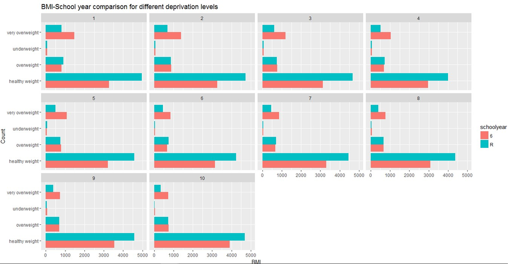

```r
p4 <- ggplot(mysample) + aes(bmipopulationcategory, fill = schoolyear)
p4 <- p4 + ggtitle("BMI-School year comparison for different deprivation levels")
p4 <- p4 + geom_bar(position = "dodge") + ylab("BMI") + xlab("Count")
p4 <- p4 + scale_fill_discrete() + coord_flip()
p4 <- p4 + facet_wrap(~schoolindexofmultipledepriv)
```